# Exc3

2023-05-25

#Problem 1

```r
library(ISLR)
Auto <- subset(Auto, select = -name) #remove the predictor name
# Auto$origin <- factor(Auto$origin)
summary(Auto)
```

```
##       mpg          cylinders      displacement     horsepower        weight
##  Min.   : 9.00   Min.   :3.000   Min.   : 68.0   Min.   : 46.0   Min.   :1613
##  1st Qu.:17.00   1st Qu.:4.000   1st Qu.:105.0   1st Qu.: 75.0   1st Qu.:2225
##  Median :22.75   Median :4.000   Median :151.0   Median : 93.5   Median :2804
##  Mean   :23.45   Mean   :5.472   Mean   :194.4   Mean   :104.5   Mean   :2978
##  3rd Qu.:29.00   3rd Qu.:8.000   3rd Qu.:275.8   3rd Qu.:126.0   3rd Qu.:3615
##  Max.   :46.60   Max.   :8.000   Max.   :455.0   Max.   :230.0   Max.   :5140
##   acceleration        year           origin
##  Min.   : 8.00   Min.   :70.00   Min.   :1.000
##  1st Qu.:13.78   1st Qu.:73.00   1st Qu.:1.000
##  Median :15.50   Median :76.00   Median :1.000
##  Mean   :15.54   Mean   :75.98   Mean   :1.577
##  3rd Qu.:17.02   3rd Qu.:79.00   3rd Qu.:2.000
##  Max.   :24.80   Max.   :82.00   Max.   :3.000
```

Origin are either american (Origin = 1), japanese.. and so on. Here we have to let R know that this is a qualitiativ variable, and not a quantitative. Origin does not have any numerical meaning, so we do not want this to influence the numerical prediction. This is done by:

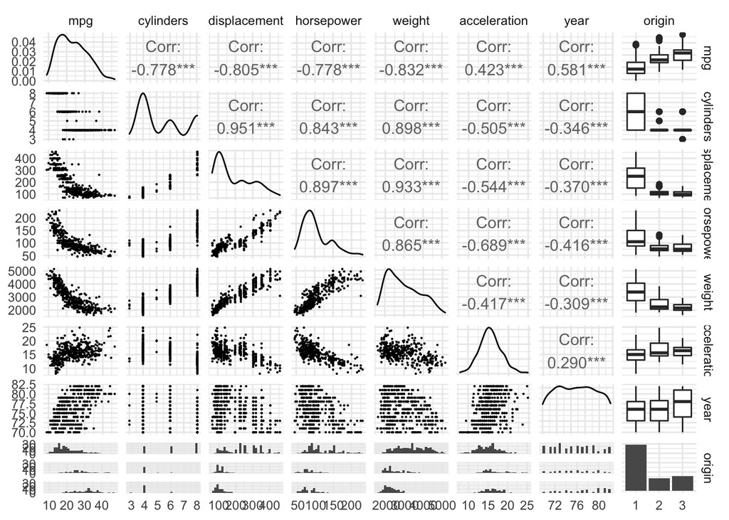

```r
Auto$origin <- factor(Auto$origin)

#make a scatter plot of all the variables in the dataset
require(GGally)
ggpairs(Auto, lower = list(continuous = wrap("points", size = 0.1))) +
  theme_minimal()
```

See that the origin row is changed from what it was before, in exercise 2.

```r
corrMatrix <- cor(Auto[, c(1:7)])

corrMatrix
```

```
##                     mpg  cylinders displacement horsepower     weight
## mpg           1.0000000 -0.7776175   -0.8051269 -0.7784268 -0.8322442
## cylinders    -0.7776175  1.0000000    0.9508233  0.8429834  0.8975273
## displacement -0.8051269  0.9508233    1.0000000  0.8972570  0.9329944
## horsepower   -0.7784268  0.8429834    0.8972570  1.0000000  0.8645377
## weight       -0.8322442  0.8975273    0.9329944  0.8645377  1.0000000
## acceleration  0.4233285 -0.5046834   -0.5438005 -0.6891955 -0.4168392
## year          0.5805410 -0.3456474   -0.3698552 -0.4163615 -0.3091199
##              acceleration       year
## mpg             0.4233285  0.5805410
## cylinders      -0.5046834 -0.3456474
## displacement   -0.5438005 -0.3698552
## horsepower     -0.6891955 -0.4163615
## weight         -0.4168392 -0.3091199
## acceleration    1.0000000  0.2903161
## year            0.2903161  1.0000000
```

mpg as response

```r
model1 <- lm(mpg ~., data = Auto)

summary(model1)
```

```
##
## Call:
## lm(formula = mpg ~ ., data = Auto)
##
## Residuals:
##     Min      1Q  Median      3Q     Max
## -9.0095 -2.0785 -0.0982  1.9856 13.3608
##
## Coefficients:
##                Estimate Std. Error t value Pr(>|t|)
## (Intercept)  -1.795e+01  4.677e+00  -3.839 0.000145 ***
## cylinders    -4.897e-01  3.212e-01  -1.524 0.128215
## displacement  2.398e-02  7.653e-03   3.133 0.001863 **
## horsepower   -1.818e-02  1.371e-02  -1.326 0.185488
## weight       -6.710e-03  6.551e-04 -10.243  < 2e-16 ***
## acceleration  7.910e-02  9.822e-02   0.805 0.421101
## year          7.770e-01  5.178e-02  15.005  < 2e-16 ***
## origin2       2.630e+00  5.664e-01   4.643 4.72e-06 ***
## origin3       2.853e+00  5.527e-01   5.162 3.93e-07 ***
## ---
## Signif. codes:  0 '***' 0.001 '**' 0.01 '*' 0.05 '.' 0.1 ' ' 1
##
## Residual standard error: 3.307 on 383 degrees of freedom
## Multiple R-squared:  0.8242, Adjusted R-squared:  0.8205
## F-statistic: 224.5 on 8 and 383 DF,  p-value: < 2.2e-16
```

The p value of weight indicates that there is a significant relationship between mpg and weight of the car. Looking at the above scatter plot, we see that much weight, results in small mpg When the weight is less than 2000kg, the relationship flattens.

The estimated coefficient for year is +0.77. This means that a newer car, will have an increasing mpg. (on average +0.77mpg per year)

Now we want to investigate the significance of origin. This is, however, a factor with three levels, Origin1, Origin2, Origin3. We have that Origin1 is the refrence level. The estimated coefficient to the Origin2 and 3 are the differences from the reference category, Origin1. Since we have three levels, we have to do a F-test. This is done with anova-function:

```r
anova(model1)
```

```
## Analysis of Variance Table
##
## Response: mpg
##               Df  Sum Sq Mean Sq   F value    Pr(>F)
## cylinders      1 14403.1 14403.1 1317.3788 < 2.2e-16 ***
## displacement   1  1073.3  1073.3   98.1735 < 2.2e-16 ***
## horsepower     1   403.4   403.4   36.8977 3.004e-09 ***
## weight         1   975.7   975.7   89.2447 < 2.2e-16 ***
## acceleration   1     1.0     1.0    0.0884    0.7664
## year           1  2419.1  2419.1  221.2650 < 2.2e-16 ***
## origin         2   356.0   178.0   16.2787 1.639e-07 ***
## Residuals    383  4187.4    10.9
## ---
## Signif. codes:  0 '***' 0.001 '**' 0.01 '*' 0.05 '.' 0.1 ' ' 1
```

The p-value of origin indicates that there is a significant relationship between mpg and origin.

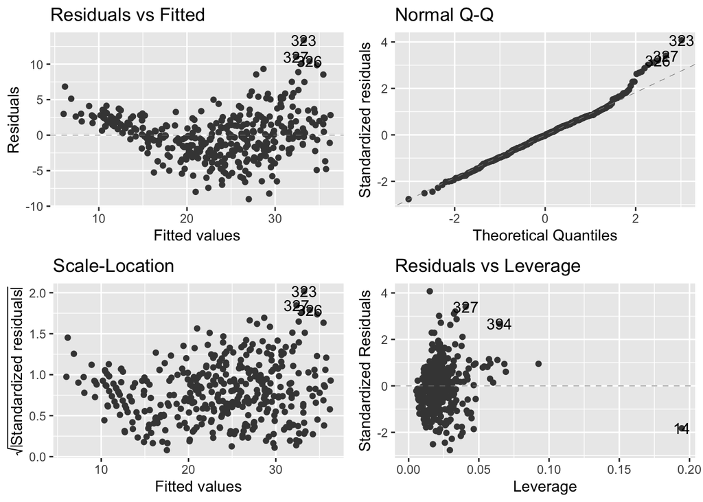

```r
library(ggfortify)
autoplot(model1, smooth.colour = NA)
```

We have a clear tendency in the residuals vs fitted plot. We want the points to be randomly scattered around zero. Hence, all residuals do not have the same variance. In addition, the normal qq plot indicate some deviation from the line towards the end. However, the normality assumption seems to be ok. Moreover, in the residuals vs leverage plot, the 14th has high leverage, hence we should check if this observation is an outlier. A large leverage indicate that this observation influence the estimation results, and that the values of x_i are unusual.

Normal QQ-plot of observations drawn from a normal distrubution:

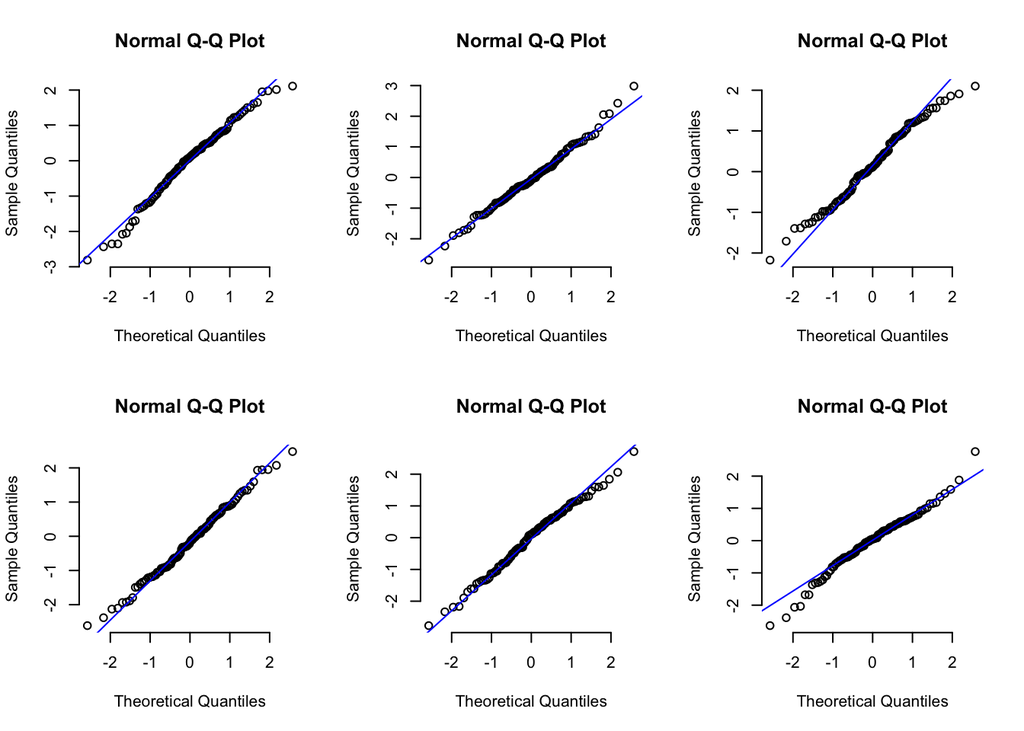

```r
set.seed(2332)
n <- 100

par(mfrow = c(2, 3))
for (i in 1:6){
  sim <- rnorm(n)
  qqnorm(sim, pch = 1, frame = FALSE)
  qqline(sim, col = "blue", lwd = 1)
}
```

7. Interactions:

```r
model2 <- lm(mpg ~ displacement + weight + year + origin*year, data= Auto)

summary(model2)
```

```
##
## Call:
## lm(formula = mpg ~ displacement + weight + year + origin * year,
##     data = Auto)
##
## Residuals:
##     Min      1Q  Median      3Q     Max
## -8.7710 -2.0204 -0.0207  1.7045 13.0017
##
## Coefficients:
##                Estimate Std. Error t value Pr(>|t|)
## (Intercept)  -5.117e+00  5.259e+00  -0.973 0.331220
## displacement  4.803e-03  5.032e-03   0.955 0.340420
## weight       -6.685e-03  5.543e-04 -12.060  < 2e-16 ***
## year          6.152e-01  6.614e-02   9.302  < 2e-16 ***
## origin2      -3.735e+01  1.026e+01  -3.642 0.000307 ***
## origin3      -2.532e+01  9.441e+00  -2.682 0.007631 **
## year:origin2  5.187e-01  1.342e-01   3.865 0.000130 ***
## year:origin3  3.564e-01  1.213e-01   2.937 0.003514 **
## ---
## Signif. codes:  0 '***' 0.001 '**' 0.01 '*' 0.05 '.' 0.1 ' ' 1
##
## Residual standard error: 3.257 on 384 degrees of freedom
## Multiple R-squared:  0.829,  Adjusted R-squared:  0.8259
## F-statistic: 265.9 on 7 and 384 DF,  p-value: < 2.2e-16
```

```r
anova(model2)
```

```
## Analysis of Variance Table
##
## Response: mpg
##               Df  Sum Sq Mean Sq   F value    Pr(>F)
## displacement   1 15440.2 15440.2 1455.6706 < 2.2e-16 ***
## weight         1  1208.5  1208.5  113.9364 < 2.2e-16 ***
## year           1  2601.4  2601.4  245.2550 < 2.2e-16 ***
## origin         2   296.9   148.5   13.9977 1.356e-06 ***
## year:origin    2   198.9    99.5    9.3764 0.0001057 ***
## Residuals    384  4073.1    10.6
## ---
## Signif. codes:  0 '***' 0.001 '**' 0.01 '*' 0.05 '.' 0.1 ' ' 1
```